# Problem Set 1

Yi Dou

2025-09-28

## Question 1

```r
set.seed(1234)
pacman::p_load(tidyverse)

# read the dataset
tweets <- read.csv('C:\\Users\\ASUS\\Desktop\\problem-set-01-2025-Yi-Dou-513\\tweets_congress.csv')

# take a sample
tweets_sample <- tweets %>%
  filter(congress == 'senate') %>%
  sample_n(20)
tweets_sample %>%
  select(Name, text) %>%
  view()
```

I took a sample of 20 observations of senate members’ tweets. I found these tweets can be divided into two categories. The first one can be called ‘daily’. This kind of tweets don’t show the authors’ political opinions specifically, but focus on the authors’ schedule or festivals of the country. The other one can be called ‘ideological’. This kind of tweets either express the authors’ political tendency directly or through commenting some specific events. I also noticed some tweets contains an ‘@’ to show it’s a retweet or a ‘#’ to include a topic. Another important finding is the texts only contains the first few sentences of the tweets, and end with a link.

## Question 2

```r
pacman::p_load(quanteda)
set.seed(1234)

# remove the link
tweets$text <- str_replace(tweets$text, "https.*$", "")

# convert to corpus
tweets_corpus <- corpus(tweets, text_field = "text")

# pre-process and convert to dfm
tweets_dfm <- tweets_corpus %>%
  tokens(remove_punct = FALSE,
         remove_numbers = TRUE,
         verbose = FALSE) %>%
  tokens_replace(pattern = "[[:punct:]&&[^#@]]+",
                 replacement = "",
                 valuetype = "regex") %>%
  tokens_tolower() %>%
  tokens_remove(stopwords("en")) %>%
  tokens_wordstem() %>%
  dfm()

print(tweets_dfm)
```

```
## Document-feature matrix of: 1,266,542 documents, 216,787 features (>99.99% sparse) and 9 docvars.
##        features
## docs      privileg help constitu navig issu feder agenc listen concer
##   text1 2        1    1        1     1    1     1     1      1      1
##   text2 2        0    0        0     0    0     0     0      0      0
##   text3 5        0    0        0     0    0     0     0      0      0
##   text4 3        0    0        0     0    0     0     0      0      0
##   text5 2        0    0        0     0    0     0     0      0      0
##   text6 2        0    1        0     0    0     0     0      0      0
## [ reached max_ndoc ... 1,266,536 more documents, reached max_nfeat ... 216,777 more features ]
```

I removed the link at the end of each tweet, because it doesn’t contain information we need. I also removed punctuation, numbers and end words as the common steps of pre-processing. I think a step we should not use is to remove all the punctuation marks, because this will remove “#” and “@” which have meaning in tweet context. I had been worried that the “remove_punct = TRUE” argument would remove “#” and “@” as well, so I tried to maintained them manually.

## Question 3

```r
pacman::p_load("preText")
set.seed(1234)

# convert the sample to corpus
tweets_sample$text <- str_replace(tweets_sample$text, "https.*$", "")
tweets_sample_corpus <- corpus(tweets_sample, text_field = "text")

# do the preText
preprocessed_tweets <- factorial_preprocessing(
    tweets_sample_corpus,
    verbose = FALSE)
```

```
## Preprocessing 20 documents 128 different ways...
```

```r
preText_results <- preText(
    preprocessed_tweets,
    dataset_name = "Tweets",
    distance_method = "cosine",
    num_comparisons = 20,
    verbose = FALSE)
```

```
## Generating document distances...
## Generating preText Scores...
## Generating regression results..
## The R^2 for this model is: 0.7368651
## Regression results (negative coefficients imply less risk):
##                  Variable Coefficient    SE
## 1               Intercept       0.149 0.005
## 2      Remove Punctuation      -0.013 0.004
## 3          Remove Numbers       0.000 0.004
## 4               Lowercase       0.001 0.004
## 5                Stemming       0.001 0.004
## 6        Remove Stopwords      -0.048 0.004
## 7 Remove Infrequent Terms       0.000 0.004
## 8              Use NGrams      -0.048 0.004
## Complete in: 4.5 seconds...
```

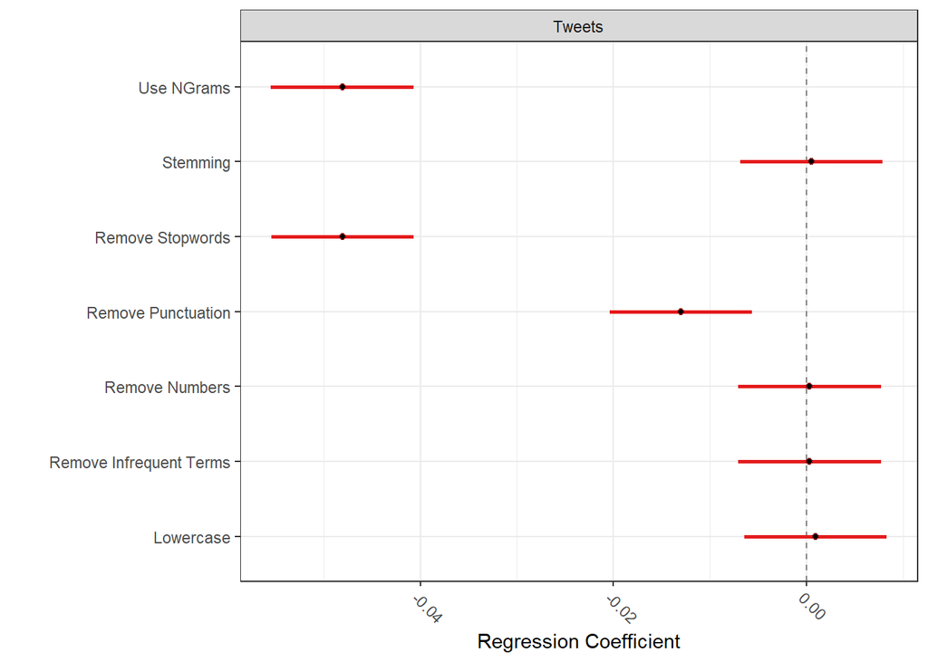

```r
# visualization
regression_coefficient_plot(preText_results,
                            remove_intercept = TRUE)
```

According to preText, using ngrams, removing stopwords and removing punctuations will produce more “normal” results, and none of these steps will produce more unusual results. Therefore, the I would keep all these steps.

## Queations 4

```r
set.seed(1234)

# subgroup by party
dfm_grouped <- dfm_group(tweets_dfm, Party)
dfm_grouped <- dfm_subset(dfm_grouped, docid_ %in% c("D", "R"))
print(dfm_grouped)
```

```
## Document-feature matrix of: 2 documents, 216,787 features (38.10% sparse) and 1 docvar.
##     features
## docs         privileg  help constitu navig issu feder agenc listen concer
##    D 2583224     1032 31773     3595   556 7371 14876  2226   2930     19
##    R 1917602     1217 18293     2349   373 7011  8853  1598   3486     30
## [ reached max_nfeat ... 216,777 more features ]
```

```r
# calculate the log ratio of share, using alpha = 0.5 as a smoother
alpha <- 0.5
counts <- as.matrix(dfm_grouped)
shares <- sweep(counts + alpha, 1, rowSums(counts + alpha), "/")
gD <- rownames(shares)[1]
gR <- rownames(shares)[2]
log_ratio <- log(shares[gD, ] / shares[gR, ])

# present the results
results <- tibble(
  feature = colnames(dfm_grouped),
  log_ratio = as.numeric(log_ratio),
  share_D = as.numeric(shares[gD, ]),
  share_R = as.numeric(shares[gR, ]),
  freq_D  = as.numeric(counts[gD, ]),
  freq_R  = as.numeric(counts[gR, ])
)
results %>%
  arrange(log_ratio) %>%
  select(feature, log_ratio) %>%
  head(5)
```

```
## # A tibble: 5 × 2
##   feature            log_ratio
##   <chr>                  <dbl>
## 1 @republicanstudi       -8.00
## 2 #bidenbordercrisi      -7.71
## 3 #taxcutsandjobsact     -7.67
## 4 #al03                  -7.61
## 5 @westerncaucus         -7.47
```

```r
results %>%
  arrange(desc(log_ratio)) %>%
  select(feature, log_ratio) %>%
  head(5)
```

```
## # A tibble: 5 × 2
##   feature     log_ratio
##   <chr>           <dbl>
## 1 @usprogress      6.87
## 2 #az01            6.53
## 3 @countyofla      6.53
## 4 #va07            6.52
## 5 #tx07            6.41
```

I chose the party of congress members as the subset dimension and used log(share $word_i$ in group a/share $word_i$ in b) with a smoother to calculate which words discriminate better each group. I selected the top 5 words which has the highest and lowest value, which means they are said by almost only by one of the two parties. I found that all the words in the results have a “#” or “@”, which makes sense because these marks indicates a heavy discussion. Comparing the top words for each party, I found that republicans talks more about the Federal affairs and Democrats focuses more on state level.

## Question 5

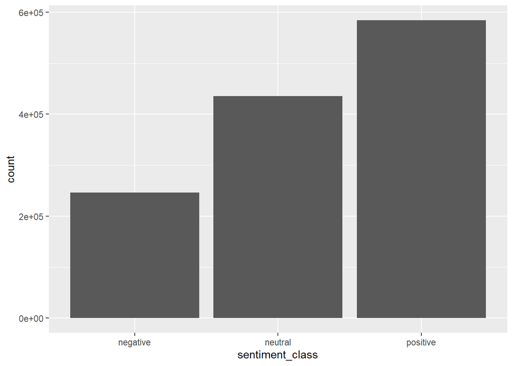

```r
set.seed(1234)
pacman::p_load("ggplot2")

# load the dictionary
pacman::p_load("quanteda.dictionaries", "quanteda.sentiment")
data(data_dictionary_LSD2015)

# get the textstat_polarity score
lsd_results <- tweets_dfm %>%
  textstat_polarity(dictionary = data_dictionary_LSD2015)
df_sent <- docvars(tweets_dfm) %>%
  mutate(doc_id=docnames(tweets_dfm)) %>%
  left_join(lsd_results)
# label the data
df_sent <- docvars(tweets_dfm) %>%
  mutate(doc_id = docnames(tweets_dfm)) %>%
  left_join(lsd_results, by = "doc_id") %>%
  mutate(
    sentiment_class = case_when(
      sentiment > 0 ~ "positive",
      sentiment < 0 ~ "negative",
      TRUE ~ "neutral"
    )
  )

# visualization
df_sent %>%
  ggplot(aes(x = sentiment_class)) +
  geom_bar()
```

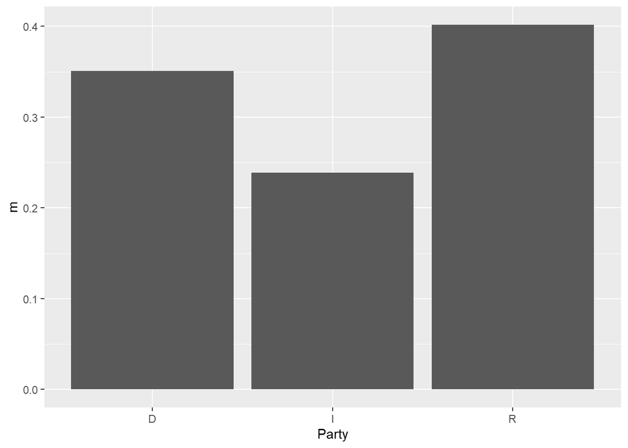

```r
df_sent %>%
  group_by(Party) %>%
  summarise(m=mean(sentiment, na.rm=TRUE)) %>%
  ggplot(aes(x = Party, y = m)) +
  geom_col()
```

I used the Lexicoder Sentiment Dictionary (from Young and Soroka) to get the textstats_polarity score and label the data. Through the visualizations, we can see that among all the texts, positive ones are the most, and then neutral, and then negative; among different parties, the Republicans’ tweets are most positive, and then the Democrats, and then the Independent. In average, all these three categories of members’ tweets are positive.

## Question 6.1

```r
pacman::p_load("quanteda.textstats")
set.seed(520)

# get the samples for each group
positive10 <- df_sent %>%
  arrange(desc(sentiment)) %>%
  slice_head(n = 10) %>%
  left_join(data.frame(text = tweets$text, date = tweets$date, author = tweets$author), by = c("date", "author"))
negative10 <- df_sent %>%
  arrange(sentiment) %>%
  slice_head(n = 10) %>%
  left_join(data.frame(text = tweets$text, date = tweets$date, author = tweets$author), by = c("date", "author"))
zero10 <- df_sent %>%
  filter(sentiment == 0) %>%
  sample_n(10) %>%
  left_join(data.frame(text = tweets$text, date = tweets$date, author = tweets$author), by = c("date", "author"))
sample30 <- bind_rows(positive10, negative10, zero10)

# covert to dfm
sample30_dfm <- sample30 %>%
  corpus(text_field = "text") %>%
  tokens(remove_punct = FALSE,
         remove_numbers = TRUE,
         verbose = FALSE) %>%
  tokens_replace(pattern = "[[:punct:]&&[^#@]]+",
                 replacement = "",
                 valuetype = "regex") %>%
  tokens_tolower() %>%
  tokens_remove(stopwords("en")) %>%
  tokens_wordstem() %>%
  dfm()

# calculate the cosine similarity
simil_sample <- textstat_simil(sample30_dfm,
               margin = "documents",
               method = "cosine")
df_simil <- as_tibble(as.matrix(simil_sample)) %>%
  mutate(names = rownames(as.matrix(simil_sample))) %>%
  select(names, everything())
df_simil[1:5, 1:5]
```

```
## # A tibble: 5 × 5
##   names       text662196 text927242 text1021638 text1241919
##   <chr>            <dbl>      <dbl>       <dbl>       <dbl>
## 1 text662196     1          0.00663      0.0355      0.0357
## 2 text927242     0.00663    1            0.280       0.0468
## 3 text1021638    0.0355     0.280        1           0.251
## 4 text1241919    0.0357     0.0468       0.251       1
## 5 text296176     0.0536     0.0703       0.377       0.378
```

```r
# example: top 10 for text662196
df_simil %>%
  arrange(desc(text662196)) %>%
  select(names,text662196) %>%
  head(11) %>%
  filter(names != "text662196")
```

```
## # A tibble: 10 × 2
##    names       text662196
##    <chr>            <dbl>
##  1 text214689      0.0675
##  2 text243575      0.0603
##  3 text785868      0.0592
##  4 text550878      0.0584
##  5 text1060079     0.0569
##  6 text456468      0.0555
##  7 text775027      0.0548
##  8 text950530      0.0537
##  9 text296176      0.0536
## 10 text59082       0.0528
```

```r
# calculate correlation
corr_sample <- textstat_simil(sample30_dfm,
               margin = "documents",
               method = "correlation")
df_corr <- as_tibble(as.matrix(corr_sample)) %>%
  mutate(names = rownames(as.matrix(corr_sample))) %>%
  select(names, everything())
df_corr[1:5, 1:5]
```

```
## # A tibble: 5 × 5
##   names       text662196 text927242 text1021638 text1241919
##   <chr>            <dbl>      <dbl>       <dbl>       <dbl>
## 1 text662196     1         -0.00167      0.0213      0.0271
## 2 text927242    -0.00167    1            0.262       0.0321
## 3 text1021638    0.0213     0.262        1           0.231
## 4 text1241919    0.0271     0.0321       0.231       1.00
## 5 text296176     0.0416     0.0495       0.352       0.364
```

```r
# example: top 10 for text662196
df_corr %>%
  arrange(desc(text662196)) %>%
  select(names,text662196) %>%
  head(11) %>%
  filter(names != "text662196")
```

```
## # A tibble: 10 × 2
##    names       text662196
##    <chr>            <dbl>
##  1 text214689      0.0596
##  2 text243575      0.0492
##  3 text785868      0.0487
##  4 text550878      0.0474
##  5 text1060079     0.0466
##  6 text456468      0.0438
##  7 text775027      0.0426
##  8 text950530      0.0418
##  9 text59082       0.0417
## 10 text296176      0.0416
```

I took 10 observations from each class(negative, positive and neutral). Then I calculated the cosine similarity and correlation for these observations with each other. Because of the limited space, I only showed the top10 for the first observation. I found that the two distance measures I used had similar results. Though they are different in magnitude, the direction and order are almost the same, which can be a validation for each other. I also foundthese numbers are relatively small. That may be because the sample size are very small.

## Question 6.2

```r
set.seed(198)

# get TF-IDF
tfidf_sample <- sample30_dfm %>%
                dfm_tfidf(scheme_tf = "prop") %>%
                dfm_group(sentiment_class, force = TRUE)

# get the key words for each group
top_pos <- topfeatures(tfidf_sample["positive", ], n = 10)
top_neu <- topfeatures(tfidf_sample["neutral", ], n = 10)
top_neg <- topfeatures(tfidf_sample["negative", ], n = 10)

top_pos
```

```
##      love     happi    energi      best     cheap     clean     thank  colleagu
## 1.2924811 0.6440500 0.5717067 0.3938990 0.3841898 0.3666667 0.2954243 0.1624126
##      true     civil
## 0.1624126 0.1624126
```

```r
top_neu
```

```
##        ⏰      hous     floor      rate        rt yesterday     spoke burdensom
## 0.2272494 0.1804231 0.1804231 0.1477121 0.1465436 0.1342838 0.1342838 0.1342838
##     power      rule
## 0.1342838 0.1342838
```

```r
top_neg
```

```
##     crisi         ✔️     biden      hate     beget      debt holocaust    terror
## 0.6808949 0.4664593 0.4664593 0.2793233 0.2332297 0.2187117 0.2110173 0.1880952
##   violenc      must
## 0.1826036 0.1740602
```

The words with higher TF-IDF for each group is very intuitive: the positive contains some good nouns and adjectives, the negative contains some cold verbs and nouns, and the neutral contains mainly words without sentiment tendency. There are two things I found interesting which may help to augment the dictionary: First, there are two expressions/emojis in the results. It makes sense, because people do use emojis a lot on social platforms. These emojis have sentiment tendency, such has the purple click may reflect a sense of sarcasm so it’s negative. To analyze people’s sentiments on social platforms, these emojis should be added into the dictionary. Second, the word “biden” is a negative word. This also makes sense, because when a politician mentions someone’s last name on twitter, he or she is more likely to criticize this person. So the people’s names, especially important politicians’ names can also be added to the dictionary.